# Biometrie onderzoek

2025-05-01

## Inleiding

Het staat je vrij een ander simpel te meten biometrisch kenmerk te onderzoeken. Voorwaarde is wel dat je twee aspecten meet (bv lichaamslengte en hoofdomtrek) en hun relatie onderzoekt, en ook dat je verschillende groepen onderzoekt (man/vrouw, jong/oud etc.). Ten slotte moeten verschillende studenten het meetwerk afwisselen en ook dat moet vastgelegd worden.

Verschilt de gemiddelde handgrootte tussen een man en een vrouw?

Wij denken dat de handen van een man gemiddeld groter zijn dan die van vrouwen.

Er zit geen verschil in gemiddelde handgrootte bij mannen en vrouwen.

### Ontwerp van het experiment

> Voor het verzamelen van de benodigde data hebben wij 33 proefpersonen gevraagd om hun handen te meten. Wij hebben willekeurig gevraagd en de ratio van man/vrouw ongeveer gelijk gehouden (17 vrouwen, 16 mannen).

### Ontwerp het protocol

#### Protocol voor meting handlengte en handbreedte

##### Benodigdheden

1. Maatlat, schuifmaat of meetlint.
2. Spreadsheet om resultaten vast te leggen, met toegang hiertoe op locaties zonder internet-toegang.
3. Je laborant-ID: een unieke *identifier* die jou als onderzoeker identificeert. Neem hiervoor de laatste 4 cijfers van je studentnummer.

##### Data verzamelen

Zoek, samen met een ander groepje van je klas, in of rond het schoolgebouw medestudenten. Vraag beleefd of ze willen participeren in een klein wetenschappelijk onderzoekje voor school waarbij de maten van de hand opgenomen zullen worden.  
Is het antwoord nee, dan groet je vriendelijk en zoek je verder.  
Is het antwoord ja, dan vraag je of de proefpersoon de hand horizontaal en gestrekt wil houden met de palm naar beneden. Vervolgens meet je zowel de lengte als de breedte van de hand op, in millimeters. Deze leg je vast in de spreadsheet, samen met je laborant-ID en een identifier (géén naam!) van de proefpersoon. Ten slotte vraag je aan de proefpersoon zijn/haar/hun sexe en legt deze vast. Wil de proefpersoon deze niet geven, of is die nonbinair, dan leg je dit vast als “anders/onbekend”. Het “parallel groepje” (dat niet jouw bevindingen mag horen) doet dezelfde meting en slaat deze met dezelfde participant identifier op.  
Bedank de proefpersoon voor deelname.  
Wissel de metingen af tussen de verschillende studenten in jouw groepje.

Ga door totdat van voldoende proefpersonen de gegevens zijn verzameld.

## Uitvoering

Je moet de onderzoeksresultaten in deze vorm opslaan:

```
laborant_ID,subject_ID,handlengte,handbreedte,sexe
3241,G1_03,113,104,m
```

## Analyse

### Lees je eigen data in

Om data vanuit een tekstbestand in te lezen kan je dit codeblok gebruiken, aannemend dat je data er exact zo uitzien als in bovenstaande voorbeeld:

```r
data_file <- "hand_data.csv"

#data format: laborant_ID,subject_ID,handlengte,handbreedte,sexe
biometric_data <- read.table(file = data_file,
                        header = TRUE,
                        sep = ";")
```

Let op: als je missende data hebt moet je die specificeren door dit argument toe te voegen: `na.strings = "<jouw NA symbool>"`

### Lengte breedte ratio toevoegen aan de kolom

Dit stukje code voegt een extra kolom toe met de lengte breedte ratio.

```r
biometric_data$ratio <- biometric_data$handlengte / biometric_data$handbreedte
head(biometric_data)
```

```
##   laborant_ID subject_ID handlengte handbreedte sexe    ratio
## 1        5614          1        175          80    M 2.187500
## 2        9190          2        165          75    V 2.200000
## 3        5614          3        190          90    M 2.111111
## 4        5614          4        185          90    M 2.055556
## 5        9190          5        172          70    V 2.457143
## 6        5614          6        170          78    V 2.179487
```

### Gemiddelde per geslacht

Hieronder word het gemiddelde berekent van hand breedte en lengte per geslacht.

```r
biometric_data$sex <- as.factor(biometric_data$sex)
biometric_data$handlengte <- as.integer(biometric_data$handlengte)
biometric_data$handbreete <- as.integer(biometric_data$handbreedte)

# controleren of de levels inderdaad op M en V staan
levels(biometric_data$sex)
```

```
## [1] "M" "V"
```

```r
# berekent het gemiddelde van lengte
l_vrouw <-mean(biometric_data$handlengte[biometric_data$sex == "V" ])
l_man <-mean(biometric_data$handlengte[biometric_data$sex== "M"])
cat(l_vrouw,"gemiddelde handlengte van vrouw","\n",l_man,"gemiddelde handlengte van man\n")
```

```
## 172.7059 gemiddelde handlengte van vrouw
##  185.8125 gemiddelde handlengte van man
```

```r
# berekent het gemiddelde van breedte
b_vrouw <-mean(biometric_data$handbreedte[biometric_data$sex == "V" ])
b_man <-mean(biometric_data$handbreete[biometric_data$sex== "M"])
cat(b_vrouw,"gemiddelde handbreedte van vrouw","\n",b_man,"gemiddelde handbreedte van man")
```

```
## 76.41176 gemiddelde handbreedte van vrouw
##  84.4375 gemiddelde handbreedte van man
```

```r
#split over gender into list of dataframes
gender_split_data <- split(x = biometric_data,
      f = biometric_data$sexe)

#apply a function to report means of both measurements
sapply(X = gender_split_data,
       FUN = function(x){
           c(handlengte = mean(x$handlengte),
             handbreedte = mean(x$handbreedte),
             ratio = mean(x$ratio))
       })
```

```
##                      M          V
## handlengte  185.812500 172.705882
## handbreedte  84.437500  76.411765
## ratio         2.207447   2.265083
```

### Plots

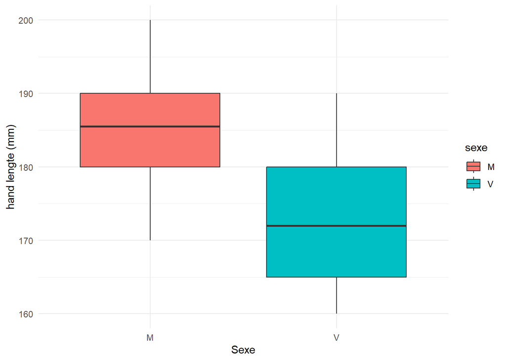

```r
library(ggplot2)
# maak de plot en voeg lagen toe
ggplot(data = biometric_data,
       mapping = aes(x = sexe, y = handlengte, fill = sexe)) +
    geom_boxplot() +                            # boxplot visualisatie
    labs(x = "Sexe", y = "hand lengte (mm)") +  # as-labels
    theme_minimal()
```

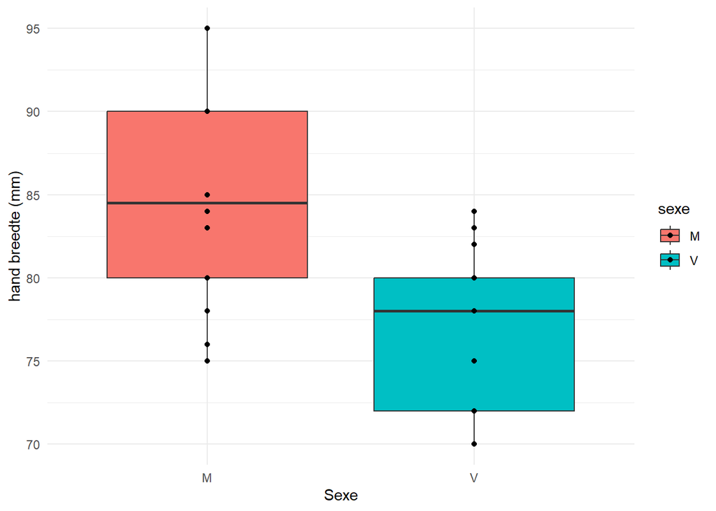

```r
#library(ggplot2) #hoeft niet nog een keer!
# maak de plot en voeg lagen toe
ggplot(data = biometric_data,
       mapping = aes(x = sexe, y = handbreedte, fill = sexe)) +
    geom_boxplot() +                            # boxplot visualisatie
    geom_point() +                              # met punten erbij
    labs(x = "Sexe", y = "hand breedte (mm)") + # as-labels
    theme_minimal()
```

### Welke verdeling?

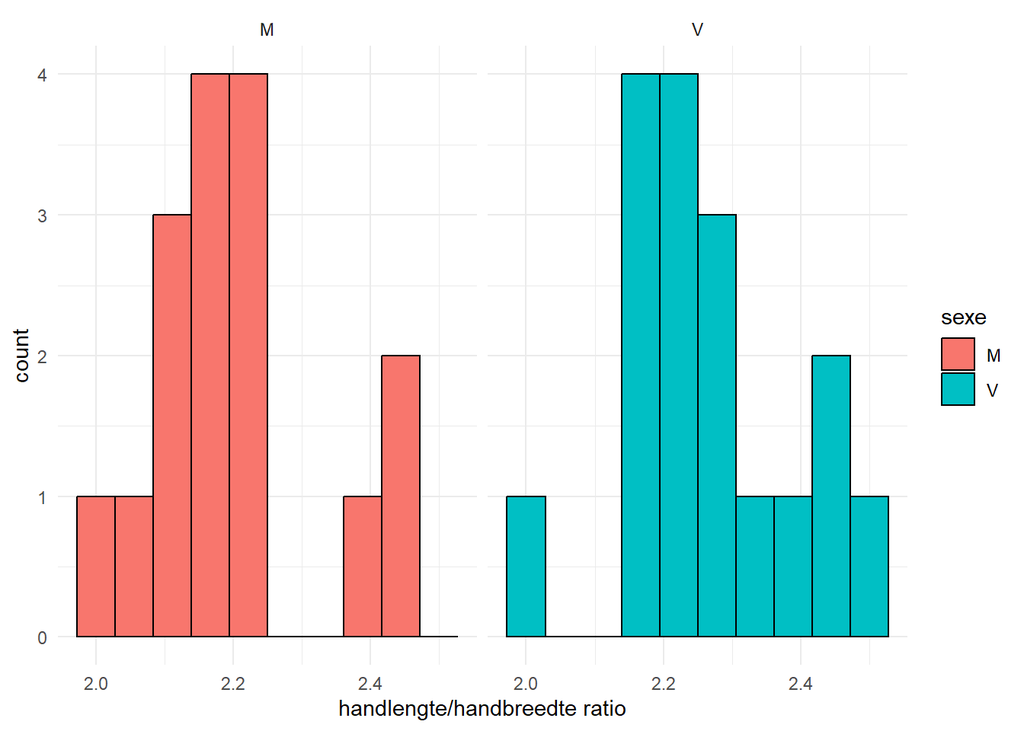

```r
ggplot(data = biometric_data,
       mapping = aes(x = ratio, fill = sexe)) +
    geom_histogram(bins = 10, colour = "black") + # histogram layer with 10 bins
    facet_wrap(. ~ sexe) +                       # split plots over gender
    labs(x = "handlengte/handbreedte ratio") +
    theme_minimal()
```

Hoe kleiner de steekproefgrootte (*sample size*) hoe lastiger het is de onderliggende verdeling vast te stellen. Speel maar eens met dit blokje code, en verander de steekproefgrootte (`n=`) in de `rnorm()` functie en de `breaks=` in de `hist()` functie. Neem voor *n* bijvoorbeeld achtereenvolgens 10, 100, 1000, 10000, 10000 en voor *breaks* 5, 10, 50. Wanneer zie je een echte normaalverdeling verschijnen?

**Dit *experiment* met de argumenten van `rnorm()` en `hist()` moet je opnemen in je eigen RMarkdown.**  
Beantwoord deze vragen:

1. Wat gebeurt er met de vorm van de verdeling als `n` groter wordt? _de verdeling van de kolom zou meer lijken op een normale verdeling.Dit komt door de limietstelling.

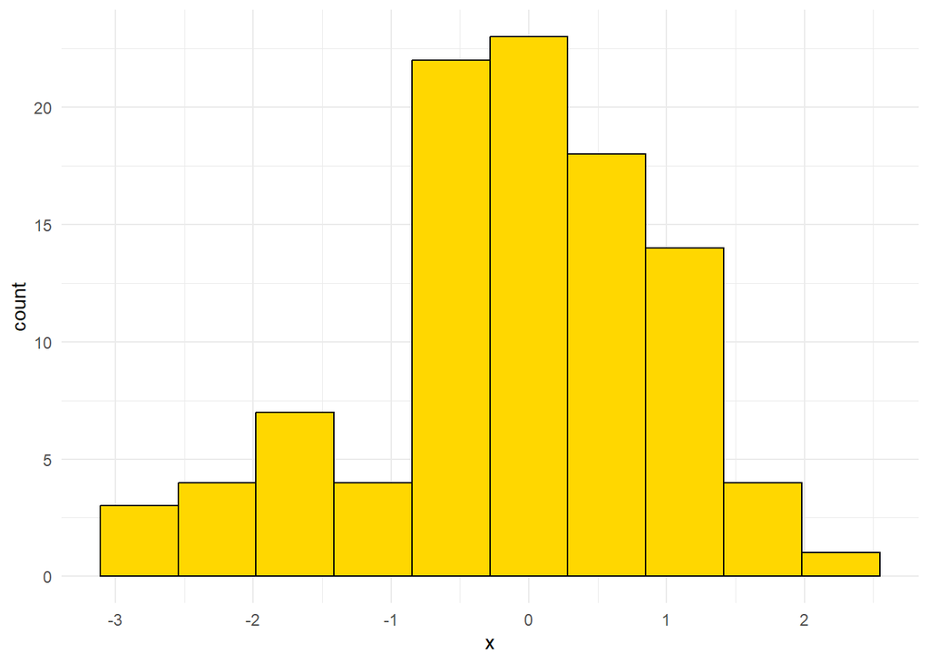

```r
hist_data <- data.frame(x = rnorm(n = 100))
ggplot(data = hist_data,
       mapping = aes(x = x)) +
    geom_histogram(bins = 10, fill = "gold", colour = "black") +
    theme_minimal()
```

   De spreiding van de steekproefgemiddelde neemt af, uiteindelijk krijg je minder spreiding hiertussen en dat zie je ook in het plot.

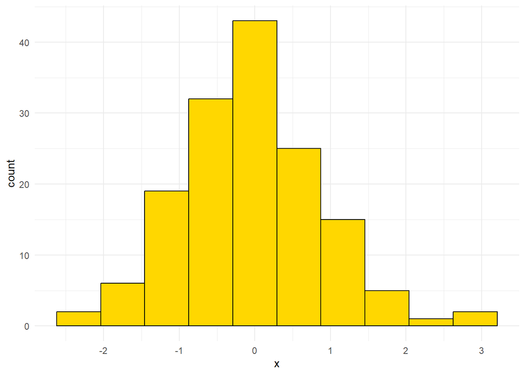

   ```r
   hist_data <- data.frame(x = rnorm(n = 150))
   ggplot(data = hist_data,
          mapping = aes(x = x)) +
       geom_histogram(bins = 10, fill = "gold", colour = "black") +
       theme_minimal()
   ```

3. Waarom is bij zelfde instellingen voor `n` en `breaks` de uitkomst toch verschillend? vanwege de willekeurigheid in gegenereerde data.

   Dat komt vanwege de willekeurigheid…elke steekproef representeert een andere set van de proef.
4. Welke minimale `n` geeft het meeste kans om een echte normaalverdeling te zien?

   minimaal 30
5. Wat voor bijzonders is er aan de hand met het `breaks` argument? Geeft de documentatie daar een verklaring voor? bepaald waar onderbrekingen (ticks) op de assen van de grafiek verschijnen. Dit helpt vooral bij het aanpassen van de assen.

   de ggplot2 kan breaks op specifieke locaties voor de assen defineren. Dit is nuttig voor leesbaarheid en interpertatie van de grafiek.

   How to Set Axis Breaks in ggplot2 (With Examples), dit is een link naar de website waar ik dit gevonden heb.

Ook kan ggplot2 gebruikt worden om beide variabelen uit te splitsen,

9190 = Johanna

5614 = Joris

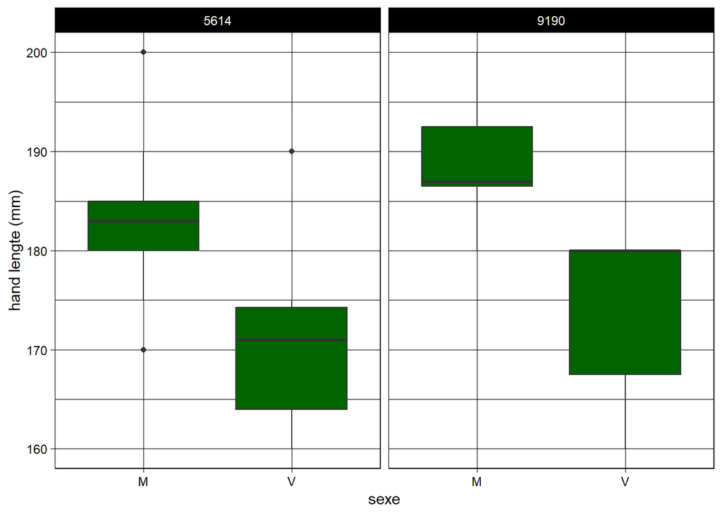

```r
ggplot(data = biometric_data,
       mapping = aes(x = sexe, y = handlengte)) +
    geom_boxplot(fill = "darkgreen") +
    facet_wrap(. ~ laborant_ID) +
    ylab("hand lengte (mm)") +
    theme_linedraw()
```

## Reflectie op het experiment

Bespreek in je groep de volgende vragen en voeg de antwoorden toe aan je uitgewerkte onderzoeksdocument.

1. Zijn de metingen tussen de verschillende meters ook (significant) verschillend? Zo ja, waardoor zou je de verschillen kunnen verklaren?
2. Onderzoek de verschillen tussen mannen en vrouwen met betrekking tot hand lengte, handbreedte en de ratio.
3. Zou je het protocol aanpassen na deze ervaring, of was hij voldoende duidelijk en reproduceerbaar?

# Onze data verwerkt

```r
laboranten <- unique(biometric_data$laborant_ID)

# Per laborant samenvatten
for (lab in laboranten) {
  cat("\nLaborant:", lab, "\n")

  lab_data <- biometric_data[biometric_data$laborant_ID == lab, ]

  cat("Handlengte - Mean:", mean(lab_data$handlengte),
      "SD:", sd(lab_data$handlengte),
      "Median:", median(lab_data$handlengte),
      "IQR:", IQR(lab_data$handlengte),
      "Min:", min(lab_data$handlengte),
      "Max:", max(lab_data$handlengte), "\n")

  cat("Handbreedte - Mean:", mean(lab_data$handbreedte),
      "SD:", sd(lab_data$handbreedte),
      "Median:", median(lab_data$handbreedte),
      "IQR:", IQR(lab_data$handbreedte),
      "Min:", min(lab_data$handbreedte),
      "Max:", max(lab_data$handbreedte), "\n")
}
```

```
##
## Laborant: 5614
## Handlengte - Mean: 178.4667 SD: 10.89473 Median: 180 IQR: 14 Min: 160 Max: 200
## Handbreedte - Mean: 82.06667 SD: 5.945787 Median: 80 IQR: 8 Min: 72 Max: 90
##
## Laborant: 9190
## Handlengte - Mean: 179.5556 SD: 10.96638 Median: 180 IQR: 12.75 Min: 160 Max: 200
## Handbreedte - Mean: 78.83333 SD: 7.180447 Median: 79 IQR: 10 Min: 70 Max: 95
```

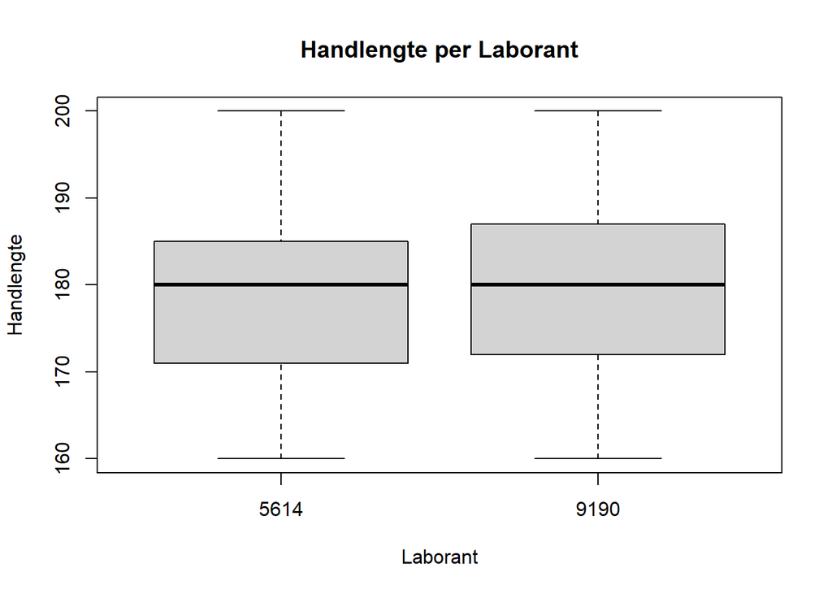

```r
# Boxplot handlengte per laborant
boxplot(handlengte ~ laborant_ID, data = biometric_data, main = "Handlengte per Laborant", xlab = "Laborant", ylab = "Handlengte")
```

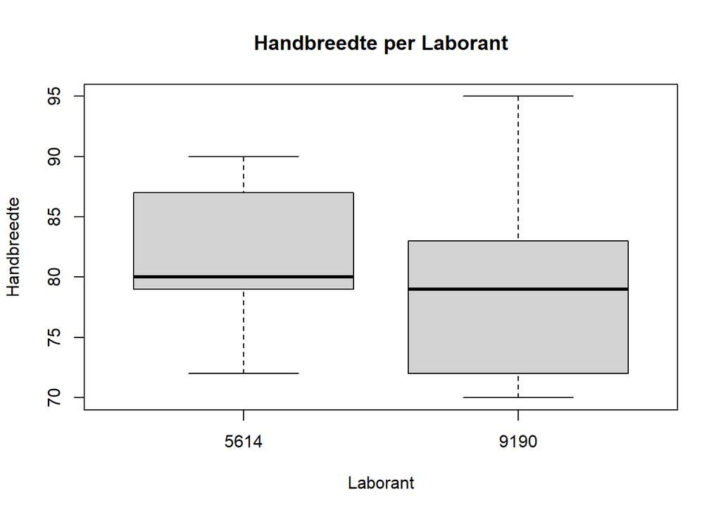

```r
# Boxplot handbreedte per laborant
boxplot(handbreedte ~ laborant_ID, data = biometric_data, main = "Handbreedte per Laborant", xlab = "Laborant", ylab = "Handbreedte")
```

```
##
## Laborant: 5614
## Shapiro-Wilk test handlengte:
##
##  Shapiro-Wilk normality test
##
## data:  lab_data$handlengte
## W = 0.97958, p-value = 0.9666
##
## Shapiro-Wilk test handbreedte:
##
##  Shapiro-Wilk normality test
##
## data:  lab_data$handbreedte
## W = 0.91211, p-value = 0.1459
```

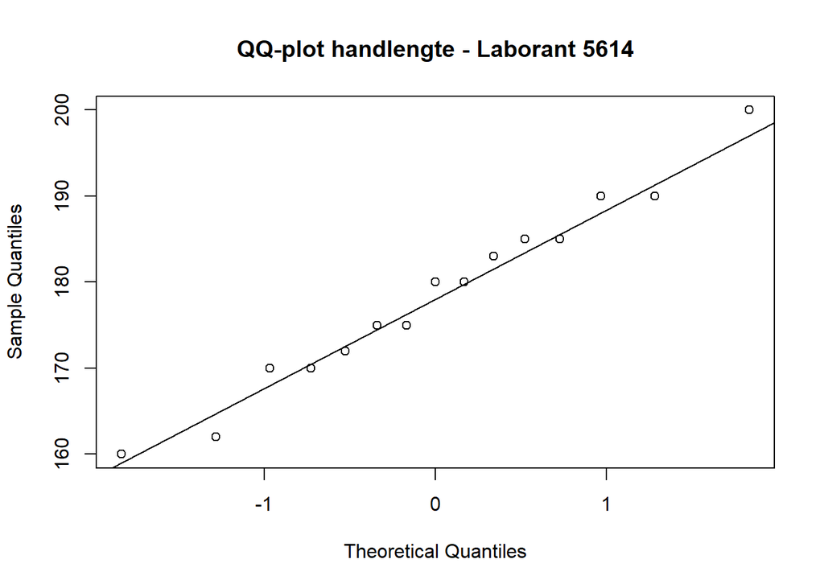

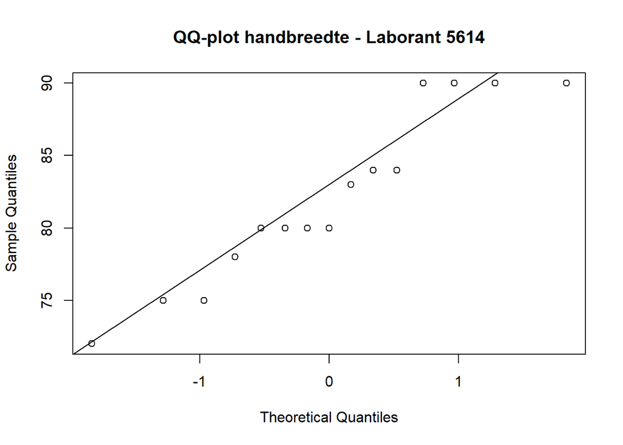

```
##
## Laborant: 9190
## Shapiro-Wilk test handlengte:
##
##  Shapiro-Wilk normality test
##
## data:  lab_data$handlengte
## W = 0.94065, p-value = 0.2973
##
## Shapiro-Wilk test handbreedte:
##
##  Shapiro-Wilk normality test
##
## data:  lab_data$handbreedte
## W = 0.93583, p-value = 0.2455
```

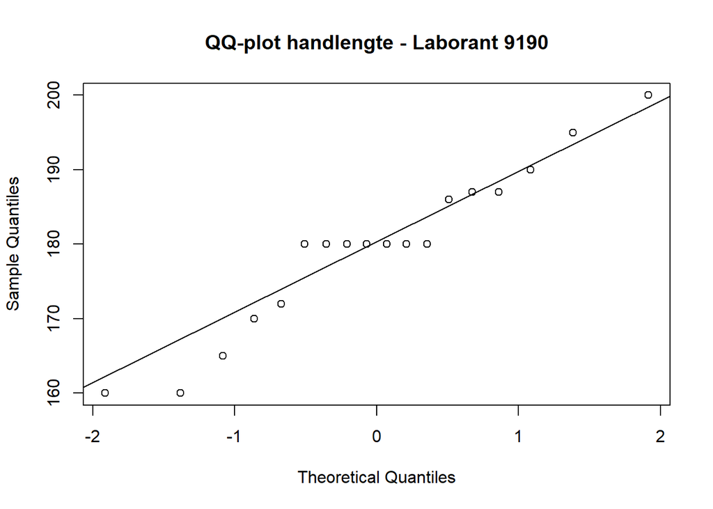

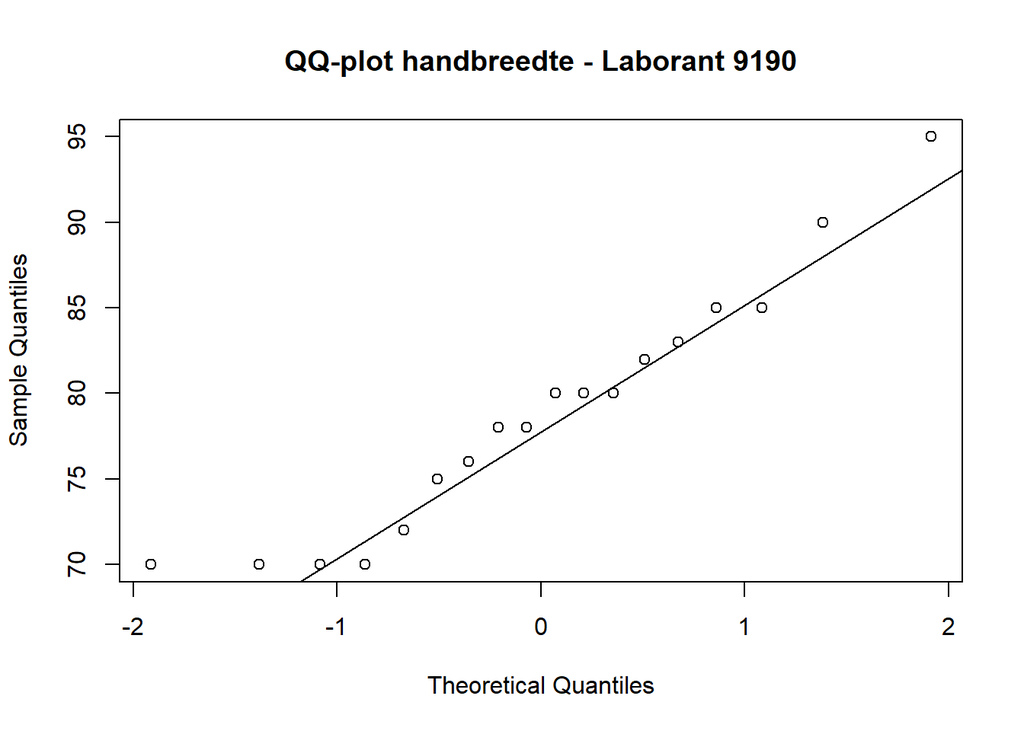

```r
for (lab in laboranten) {
  cat("\nLaborant:", lab, "\n")

  lab_data <- biometric_data[biometric_data$laborant_ID == lab, ]

  cat("Shapiro-Wilk test handlengte:\n")
  print(shapiro.test(lab_data$handlengte))

  cat("Shapiro-Wilk test handbreedte:\n")
  print(shapiro.test(lab_data$handbreedte))

  # QQ-plot handlengte
  qqnorm(lab_data$handlengte, main = paste("QQ-plot handlengte - Laborant", lab))
  qqline(lab_data$handlengte)

  # QQ-plot handbreedte
  qqnorm(lab_data$handbreedte, main = paste("QQ-plot handbreedte - Laborant", lab))
  qqline(lab_data$handbreedte)
}
```

# Andere groep hun data verwerkt

```r
data_file <- "hand_data_2e_groep.csv"

#data format: laborant_ID,subject_ID,handlengte,handbreedte,sexe
biometric_data <- read.table(file = data_file,
                        header = TRUE,
                        sep = ";")
head(biometric_data)
```

```
##   laborant_ID subject_ID handlengte handbreedte sexe
## 1           1          1        184          76    m
## 2           1          2        166          74    v
## 3           1          3        201          87    m
## 4           1          4        188          82    m
## 5           1          5        175          72    v
## 6           1          6        182          78    v
```

```r
str(biometric_data)
```

```
## 'data.frame':    33 obs. of  5 variables:
##  $ laborant_ID: int  1 1 1 1 1 1 1 1 1 1 ...
##  $ subject_ID : int  1 2 3 4 5 6 7 8 9 10 ...
##  $ handlengte : int  184 166 201 188 175 182 188 202 165 200 ...
##  $ handbreedte: int  76 74 87 82 72 78 86 85 72 97 ...
##  $ sexe       : chr  "m" "v" "m" "m" ...
```

```r
laboranten <- unique(biometric_data$laborant_ID)

# Per laborant samenvatten
for (lab in laboranten) {
  cat("\nLaborant:", lab, "\n")

  lab_data <- biometric_data[biometric_data$laborant_ID == lab, ]

  cat("Handlengte - Mean:", mean(lab_data$handlengte),
      "SD:", sd(lab_data$handlengte),
      "Median:", median(lab_data$handlengte),
      "IQR:", IQR(lab_data$handlengte),
      "Min:", min(lab_data$handlengte),
      "Max:", max(lab_data$handlengte), "\n")

  cat("Handbreedte - Mean:", mean(lab_data$handbreedte),
      # "SD:", sd(lab_data$handbreedte),
      "Median:", median(lab_data$handbreedte),
      "IQR:", IQR(lab_data$handbreedte),
      "Min:", min(lab_data$handbreedte),
      "Max:", max(lab_data$handbreedte), "\n")
}
```

```
##
## Laborant: 1
## Handlengte - Mean: 182.05 SD: 14.10664 Median: 182 IQR: 19 Min: 152 Max: 202
## Handbreedte - Mean: 79.9 Median: 78 IQR: 10.25 Min: 72 Max: 97
##
## Laborant: 2
## Handlengte - Mean: 172.9231 SD: 10.20998 Median: 174 IQR: 13 Min: 155 Max: 187
## Handbreedte - Mean: 78.15385 Median: 78 IQR: 6 Min: 59 Max: 90
```

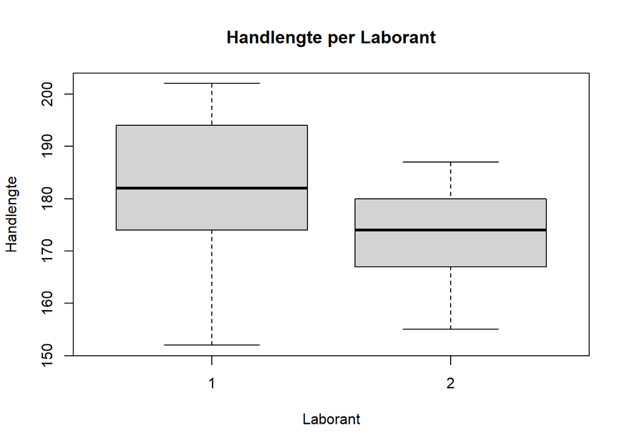

```r
# Boxplot handlengte per laborant
boxplot(handlengte ~ laborant_ID, data = biometric_data, main = "Handlengte per Laborant", xlab = "Laborant", ylab = "Handlengte")
```

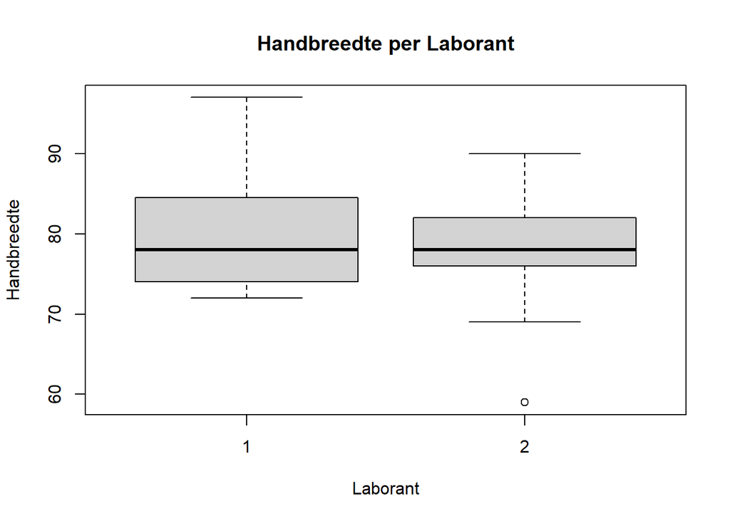

```r
# Boxplot handbreedte per laborant
boxplot(handbreedte ~ laborant_ID, data = biometric_data, main = "Handbreedte per Laborant", xlab = "Laborant", ylab = "Handbreedte")
```

```
##
## Laborant: 1
## Shapiro-Wilk test handlengte:
##
##  Shapiro-Wilk normality test
##
## data:  lab_data$handlengte
## W = 0.95469, p-value = 0.444
##
## Shapiro-Wilk test handbreedte:
##
##  Shapiro-Wilk normality test
##
## data:  lab_data$handbreedte
## W = 0.91018, p-value = 0.06423
```

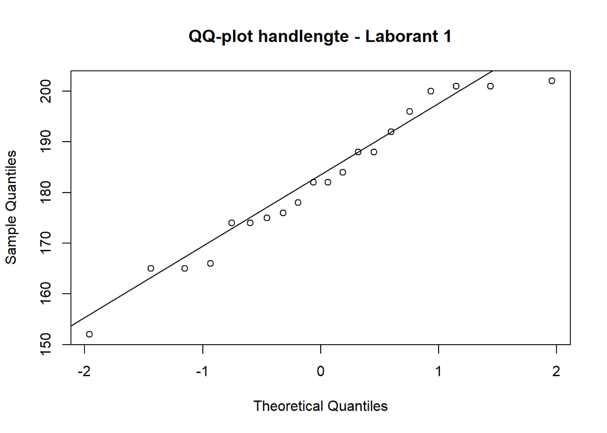

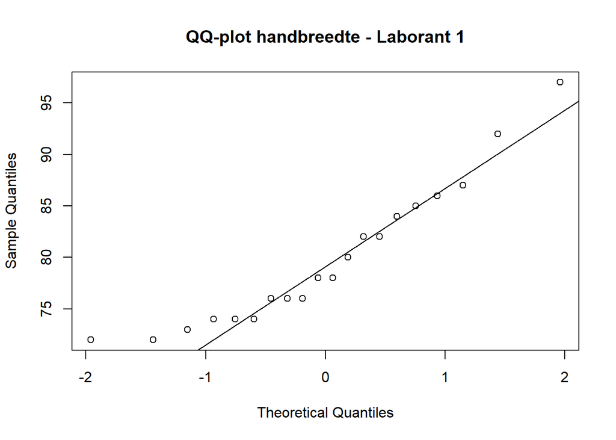

```
##
## Laborant: 2
## Shapiro-Wilk test handlengte:
##
##  Shapiro-Wilk normality test
##
## data:  lab_data$handlengte
## W = 0.95366, p-value = 0.6547
##
## Shapiro-Wilk test handbreedte:
##
##  Shapiro-Wilk normality test
##
## data:  lab_data$handbreedte
## W = 0.922, p-value = 0.2669
```

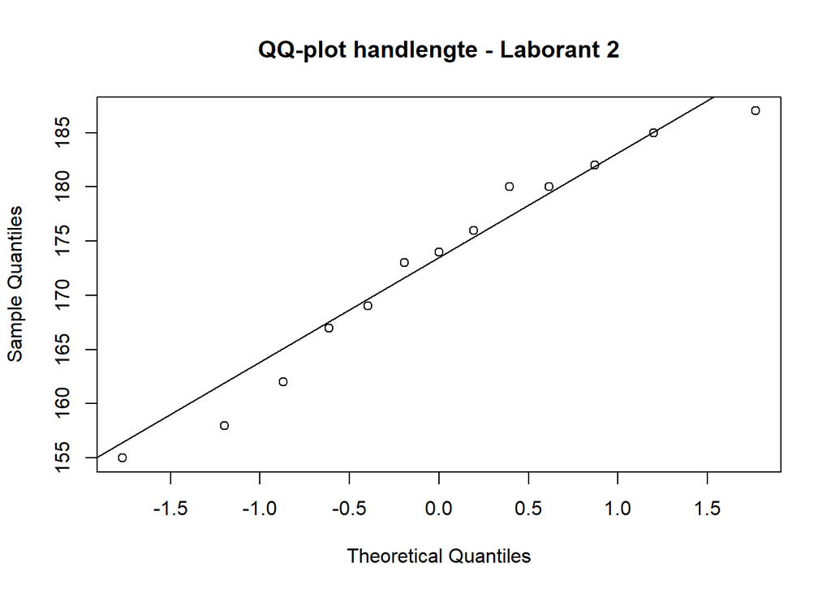

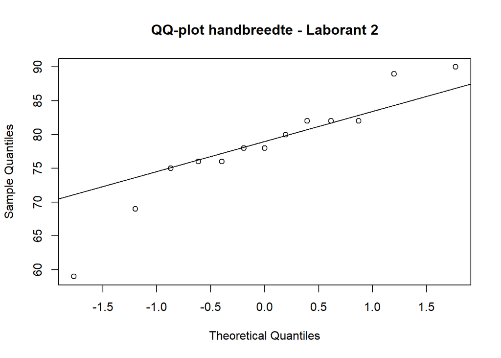

```r
for (lab in laboranten) {
  cat("\nLaborant:", lab, "\n")

  lab_data <- biometric_data[biometric_data$laborant_ID == lab, ]

  cat("Shapiro-Wilk test handlengte:\n")
  print(shapiro.test(lab_data$handlengte))

  cat("Shapiro-Wilk test handbreedte:\n")
  print(shapiro.test(lab_data$handbreedte))

  # QQ-plot handlengte
  qqnorm(lab_data$handlengte, main = paste("QQ-plot handlengte - Laborant", lab))
  qqline(lab_data$handlengte)

  # QQ-plot handbreedte
  qqnorm(lab_data$handbreedte, main = paste("QQ-plot handbreedte - Laborant", lab))
  qqline(lab_data$handbreedte)
}
```

#### Wat je moet inleveren

Voor de verwerking en analyse van je eigen data maak je gebruik van het aangeleverde template RMarkdown document. Daarin doorloop je dezelfde onderzoek stappen als hieronder, maar dan met je eigen data. Aan het einde van de dag gaat dat document, in originele en “geknitte” vorm, samen met je databestand, in een git repo die is opgezet volgens voorschift in de cursushandleiding. De link hiernaar toe gaat in je portfolio op eJournal. Let op dat je *alle* stappen hebt doorlopen voordat je inlevert. Gebruik ook de RStudio spellingscontrole!